# Analisis Popularitas dan Pendapatan Genre Film pada Database Sakila

Nafidatul Fatimah | M0725083

2026-05-26

# A. Pendahuluan

Database **Sakila** merupakan database yang disediakan oleh MySQL untuk menggambarkan tentang sistem penyewaan film. Pada analisis ini dilakukan pengamatan terhadap hubungan antara **popularitas genre film** dengan **pendapatan yang dihasilkan**. Analisis dilakukan dengan tujuan untuk mengetahui:

1. Genre film yang paling sering disewa.
2. Genre yang menghasilkan pendapatan terbesar.
3. Hubungan antara jumlah rental dan total pendapatan.

# B. Persiapan data

## 1. Import Library

```r
library(DBI)
library(odbc)
library(dplyr)
library(ggplot2)
```

## 2. Koneksi Database

```r
# Melakukan koneksi ke database
skla = dbConnect(odbc(),
               Driver = "MySQL ODBC 8.0 ANSI Driver",
               Server = "127.0.0.1",
               UID = "root",
               PWD = "admin123",
               Port = 3306,
               database = "sakila")
```

# C. Pengambilan Data

## 1. Deskripsi Insight Data

Data yang diambil merupakan data transaksi penyewaan film berdasarkan kategori atau genre film pada database Sakila. Variabel yang digunakan:

- **genre** = nama kategori film.
- **total_rental** = jumlah penyewaan film.
- **total_revenue** = total pendapatan dari penyewaan.
- **avg_payment** = rata-rata pembayaran tiap transaksi. Analisis ini bertujuan untuk mengetahui genre yang paling populer dan paling menguntungkan.

## 2. Query SQL

```r
genre_data = dbGetQuery(skla, "SELECT c.name AS genre, COUNT(r.rental_id) AS total_rental, SUM(p.amount) AS total_revenue,
    AVG(p.amount) AS avg_payment
FROM category c
JOIN film_category k ON c.category_id = k.category_id
JOIN film f ON k.film_id = f.film_id
JOIN inventory i ON f.film_id = i.film_id
JOIN rental r ON i.inventory_id = r.inventory_id
JOIN payment p ON r.rental_id = p.rental_id
GROUP BY c.name
ORDER BY total_revenue DESC;")
```

## 3. Menampilkan Data

```r
# Menampilkan Data

head(genre_data)
```

```
##       genre total_rental total_revenue avg_payment
## 1    Sports         1179       5314.21    4.507388
## 2    Sci-Fi         1101       4756.98    4.320599
## 3 Animation         1166       4656.30    3.993396
## 4     Drama         1060       4587.39    4.327726
## 5    Comedy          941       4383.58    4.658427
## 6    Action         1112       4375.85    3.935117
```

```r
# Statistik Deskriptif
summary(genre_data)
```

```
##     genre            total_rental  total_revenue   avg_payment
##  Length:16          Min.   : 830   Min.   :3418   Min.   :3.856
##  Class :character   1st Qu.: 940   1st Qu.:3706   1st Qu.:3.979
##  Mode  :character   Median : 969   Median :4276   Median :4.188
##                     Mean   :1002   Mean   :4213   Mean   :4.206
##                     3rd Qu.:1096   3rd Qu.:4435   3rd Qu.:4.405
##                     Max.   :1179   Max.   :5314   Max.   :4.658
```

# D. Visualisasi Data

## 1. Popularitas Genre Berdasarkan Jumlah Rental

```
## Defaulting to continuous.
```

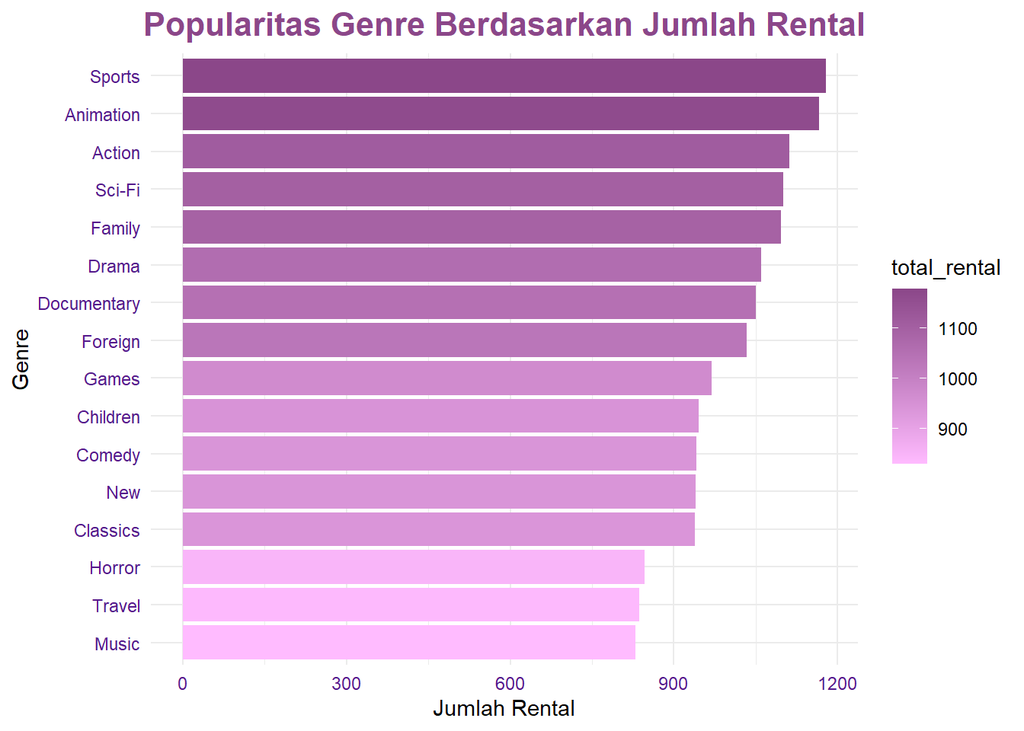

```r
ggplot(genre_data, aes(x = reorder(genre, total_rental),
           y = total_rental,
           fill = total_rental)) +
  geom_bar(stat = "identity") +
  coord_flip() +
  labs(
    title = "Popularitas Genre Berdasarkan Jumlah Rental",
    x = "Genre",
    y = "Jumlah Rental"
  ) +
  scale_fill_gradient(low = "plum1", high = "orchid4") +
  theme_minimal() +
  theme(
    plot.title = element_text(
      hjust = 0.5,
      size = 16,
      face = "bold",
      color = "orchid4"
    ),
    axis.text = element_text(color = "purple4")
  )
```

### 1.1 Interpretasi

Berdasarkan grafik batang di atas, kita dapat melihat distribusi popularitas genre film di Database Sakila secara berurutan. Genre **Sports** menempati posisi tertinggi dengan total rental terbanyak, hal ini menjadikannya genre yang paling diminati oleh pelanggan. Sebaliknya, genre **Music** memiliki frekuensi penyewaan paling rendah selama periode ini. Dari informasi ini, dapat digunakan sebagai acuan strategi untuk memperbanyak stok film pada genre-genre populer demi meningkatkan pendapatan.

## 2. Total Pendapatan Berdasarkan Genre

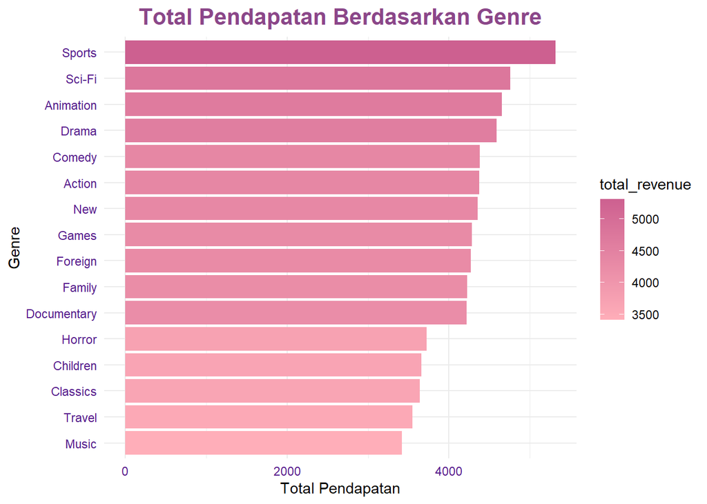

```r
ggplot(genre_data,
       aes(x = reorder(genre, total_revenue),
           y = total_revenue,
           fill = total_revenue)) +
  geom_bar(stat = "identity") +
  coord_flip() +
  labs(
    title = "Total Pendapatan Berdasarkan Genre",
    x = "Genre",
    y = "Total Pendapatan"
  ) +
  scale_fill_gradient(low = "lightpink1", high = "hotpink3") +
  theme_minimal() +
  theme(
    plot.title = element_text(
      hjust = 0.5,
      size = 16,
      face = "bold",
      color = "orchid4"
    ),
    axis.text = element_text(color = "purple4")
  )
```

### 2.1 Interpretasi

Dari grafik tersebut, genre **Sports** terbukti menjadi sumber pendapatan terbesar bagi perusahaan dengan total perolehan tertinggi dibandingkan genre lainnya. Di sisi lain, genre **Music** memberikan kontribusi pendapatan yang paling minimal.

## 3. Hubungan Popularitas Genre dan Pendapatan

### 3.1 Persamaan Matematis

Hubungan antara jumlah rental dan pendapatan dapat dituliskan dalam bentuk persamaan linear:
$$Y = a + bX$$

dengan:

- $Y$ = total pendapatan
- $X$ = jumlah rental
- $a$ = konstanta
- $b$ = koefisien regresi

### 3.2 Visualisasi Menggunakan Scatter Plot

```
## Defaulting to continuous.
```

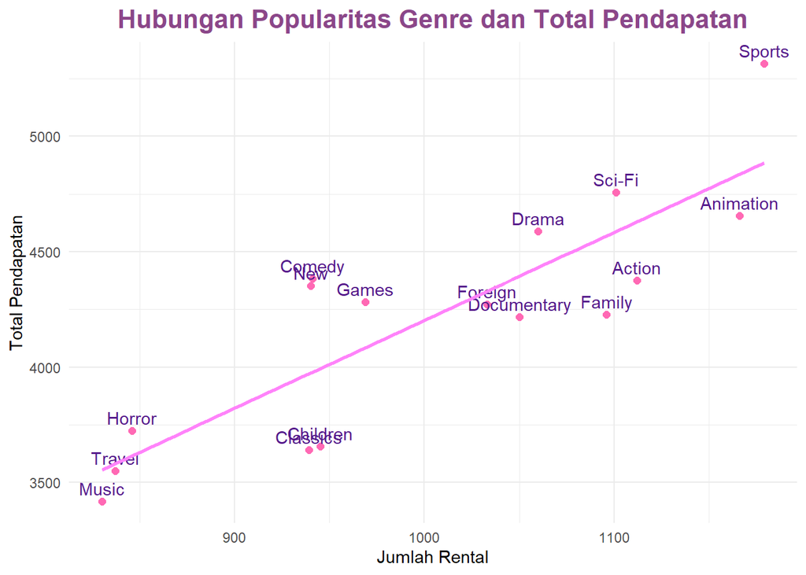

```r
ggplot(genre_data,
       aes(x = total_rental,
           y = total_revenue,
           label = genre)) +
  geom_point(size = 2, color = "hotpink") +
  geom_text(vjust = -0.5, color = "purple4") +
  geom_smooth(method = "lm",
              se = FALSE,
              color = "orchid1") +
  labs(
    title = "Hubungan Popularitas Genre dan Total Pendapatan",
    x = "Jumlah Rental",
    y = "Total Pendapatan"
  ) +
  theme_minimal() +
  theme(
    plot.title = element_text(
      hjust = 0.5,
      size = 16,
      face = "bold",
      color = "orchid4"
    )
  )
```

### 3.3 Interpretasi

Grafik scatterplot di atas memperlihatkan hubungan antara jumlah rental (popularitas) dan total pendapatan dari setiap genre film pada Database Sakila. Garis tren linear yang bergerak naik ke kanan atas menunjukkan adanya korelasi positif yang kuat antara kedua variabel. Hal ini berarti tinggi rendahnya pendapatan perusahaan sangat bergantung pada volume penyewaan film. Pola ini mengonfirmasi bahwa strategi mempertahankan atau menambah volume sewa pada genre populer akan berbanding lurus dengan peningkatan profitabilitas perusahaan.

### 3.4 Analisis Korelasi

```r
korel <- cor(genre_data$total_rental, genre_data$total_revenue)

korel
```

```
## [1] 0.8510213
```

# E. Kesimpulan

Berdasarkan hasil analisis database Sakila dapat disimpulkan bahwa:

1. Genre film tertentu memiliki tingkat popularitas yang lebih tinggi dibanding genre lainnya.
2. Genre dengan jumlah rental tinggi cenderung menghasilkan pendapatan lebih besar.
3. Terdapat hubungan positif antara jumlah rental dan total pendapatan.
4. Analisis ini dapat membantu perusahaan rental film dalam menentukan strategi bisnis dan pengelolaan koleksi film.

# F. Penutup

```r
dbDisconnect(skla)
```